# NEILYTICS

Espacio para ver el fútbol por medio de los datos

## Propósito

La idea de este sitio es poder compartir información, ejemplos, artículos, análisis, etc donde se combinan dos de mis pasiones: Fútbol y datos, en un lenguaje sencillo y al punto. Espero que me puedan acompañar y que juntos podamos aprender y disfrutar.

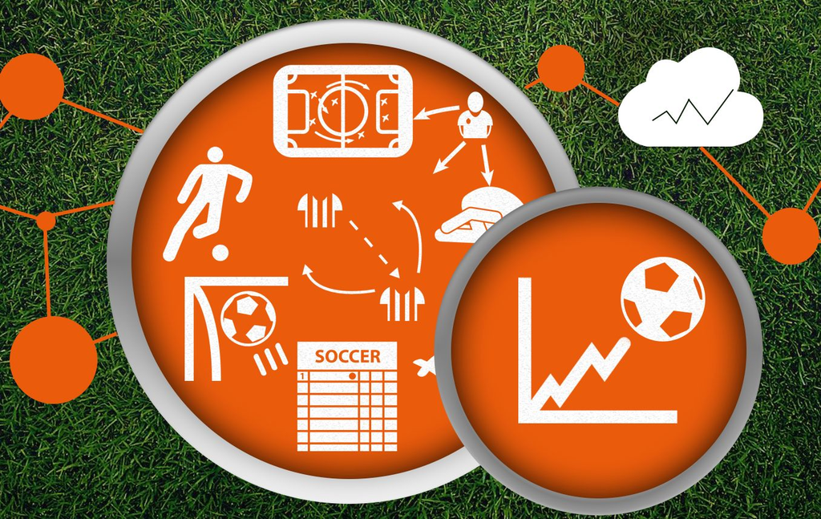

Imagen: Data Science Central

## Fuentes de datos gratuitas

Muchas veces se vuelve un poco complicado encontrar un set de datos de futbol de buena calidad que nos ayuden para algun trabajo, investigación o simplemente “jugar” un rato con ellos. Por esta razón quiero iniciar con una serie de recomendaciones de lugares, paquetes de R/Python, repositorios donde podamos encontrar valiosa información relacionada al futbol.

**1. UNDERSTAT**

Este un sitio donde podemos encontrar datos de la métrica expected goals (Goles Esperados) para las ligas de Inglaterra, España,Alemania,Italia, Francia y Rusia. Link: https://understat.com

Hay desarrollos adicionales que permiten la extracción de datos de este sitio, por ejemplo el paquete en R llamado: `understatr` , el cual pueden encontrar en el siguiente repositorio de github: https://github.com/ewenme/understatr

Con este paquete podemos extrar información por ejemplo de determinado equipo en determinada temporada, a continuación extraeremos datos de mi querido Liverpool para esta temporada que recien ha finalizado:

```r
library(understatr)

#Generamos los datos para el LFC de la temporada 2021
team_players_stats <- understatr::get_team_players_stats('Liverpool','2021')

#Previsualizamos los datos
head(team_players_stats)
```

```
## # A tibble: 6 x 19
##   player_id player_name   games  time goals    xG assists    xA shots key_passes
##       <dbl> <chr>         <dbl> <dbl> <dbl> <dbl>   <dbl> <dbl> <dbl>      <dbl>
## 1      1250 Mohamed Salah    37  3085    22 20.3        5  6.53   126         55
## 2       838 Sadio Mané       35  2805    11 14.8        7  7.79    94         61
## 3       482 Roberto Firm…    36  2882     9 12.9        7  6.12    83         44
## 4      6854 Diogo Jota       19  1114     9  7.06       0  1.76    46         12
## 5       771 Georginio Wi…    38  2961     2  2.82       0  1.66    31         21
## 6      1791 Trent Alexan…    36  3040     2  2.59       7  8.58    55         77
## # … with 9 more variables: yellow_cards <dbl>, red_cards <dbl>, position <chr>,
## #   team_name <chr>, npg <dbl>, npxG <dbl>, xGChain <dbl>, xGBuildup <dbl>,
## #   year <dbl>
```

Con estos datos podemos ver por ejemplo el Top 5 de Goleadores del LFC:

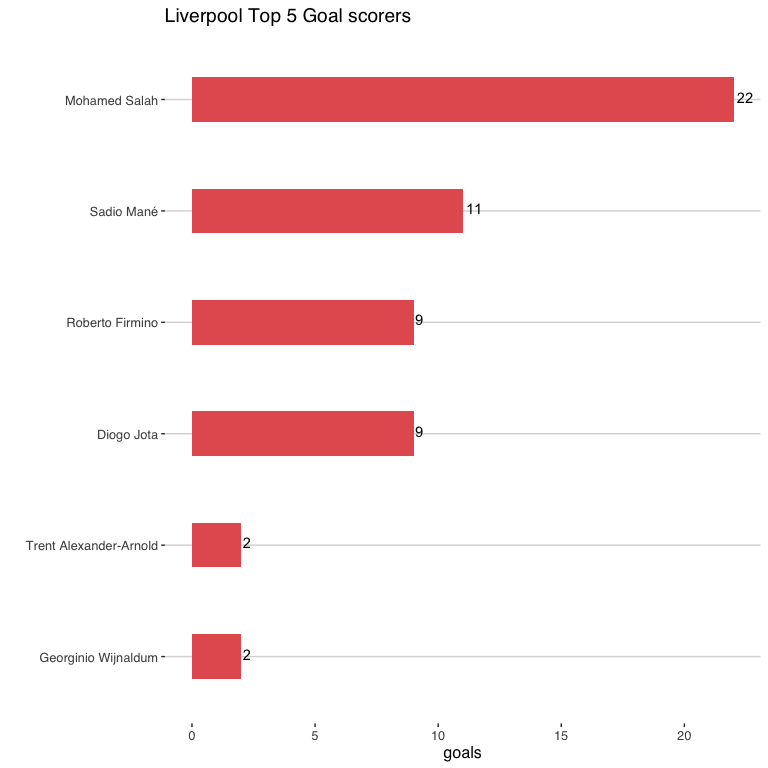

```r
library(ggplot2)
library(dplyr)
library(forcats)
library(ggthemes)

#Generamos el top basado en la cantidad de goles
top_5 <- team_players_stats %>%
  top_n(goals, n=5)

#Creamos el gráfico
top_5 %>%
  mutate(player_name=fct_reorder(player_name,goals)) %>%
  ggplot(aes(x=player_name,y=goals)) +
  geom_bar(stat="identity",fill="#e45f5f", width=.4) +
  geom_text(aes(label=goals), position=position_dodge(width=0.9), vjust=0.25, hjust=-0.20) +
  coord_flip() +
  ggtitle("Liverpool Top 5 Goal scorers") +
  xlab("") +
  theme_hc()
```

Este es un paquete muy útil para poder conseguir información valiosa para nuestros análisis.

Hasta acá ésta primera entrega sobre fuentes de datos gratuitas, en la proxima hablaremos de: `fbref`

Pura vida!!!